# emily-works

# Data Manipulation

## Data Import

- Remove empty rows with `drop_na()`
- Remove invalid symbols with `str_replace_all()`
- Remove the “GB” text extension from the Ram column and convert it to integer using `as.integer()`
- Remove the “kg” text extension from the Weight column and convert it to numeric using `as.double()`
- Extract the continuous numerical variable representing processor clock speed in GHz from the Cpu column using `str_extract()` and convert it to numeric using `as.double()`
- Create new columns (`is_IPS` and `is_Retina`) based on the presence of specific keywords in the ScreenResolution column using `str_detect()`
- Extract the pure pixel dimensions (Width and Height) from the ScreenResolution column using `str_extract()` and converts them to integer using `as.integer()` and stores them in separate columns
- Create a new column (`OpSys`) that groups categories into broader groups using `case_when()` and `str_detect()`

Data after Manipulation

| Unnamed: 0 | Company | TypeName | Inches | ScreenResolution | Cpu | Ram | Memory | Gpu | OpSys | Weight | Price | Cpu_clock | is_IPS | is_Retina | Width | Height |
| --- | --- | --- | --- | --- | --- | --- | --- | --- | --- | --- | --- | --- | --- | --- | --- | --- |
| 0 | Apple | Ultrabook | 13.3 | 2560x1600 | Intel Core i5 2.3GHz | 8 | 128GB SSD | Intel Iris Plus Graphics 640 | macOS | 1.37 | 71378.6832 | 2.3 | TRUE | TRUE | 2560 | 1600 |
| 1 | Apple | Ultrabook | 13.3 | 1440x900 | Intel Core i5 1.8GHz | 8 | 128GB Flash Storage | Intel HD Graphics 6000 | macOS | 1.34 | 47895.5232 | 1.8 | FALSE | FALSE | 1440 | 900 |
| 2 | HP | Notebook | 15.6 | 1920x1080 | Intel Core i5 7200U 2.5GHz | 8 | 256GB SSD | Intel HD Graphics 620 | No OS | 1.86 | 30636 | 2.5 | FALSE | FALSE | 1920 | 1080 |
| 3 | Apple | Ultrabook | 15.4 | 2880x1800 | Intel Core i7 2.7GHz | 16 | 512GB SSD | AMD Radeon Pro 455 | macOS | 1.83 | 135195.336 | 2.7 | TRUE | TRUE | 2880 | 1800 |
| 4 | Apple | Ultrabook | 13.3 | 2560x1600 | Intel Core i5 3.1GHz | 8 | 256GB SSD | Intel Iris Plus Graphics 650 | macOS | 1.37 | 96095.808 | 3.1 | TRUE | TRUE | 2560 | 1600 |

# Visualization

I’ll first convert the price to USD for better interpretability, assuming an exchange rate of 1 USD = 83 INR.

## 1. Price vs. Numeric Features

### RAM & Price

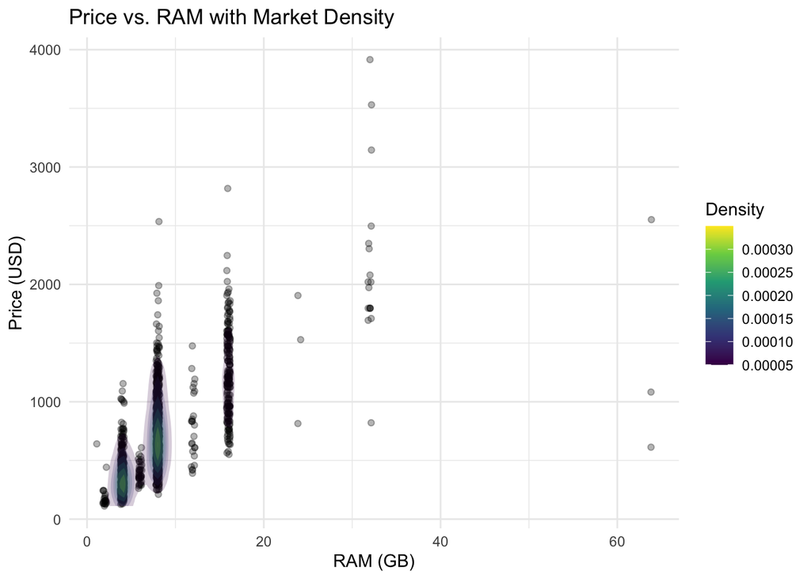

### CPU & Price

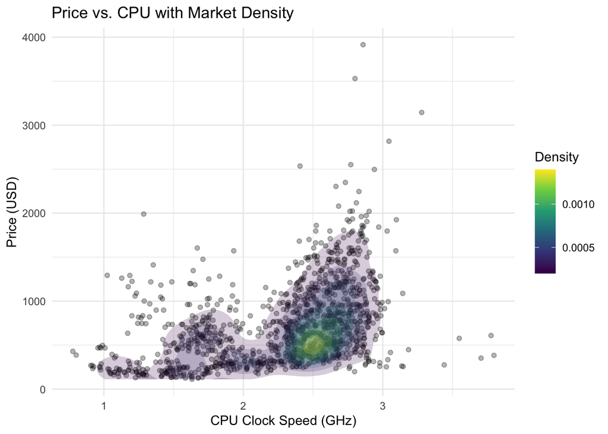

### Weight & Price

[figure not shown]

### By Company

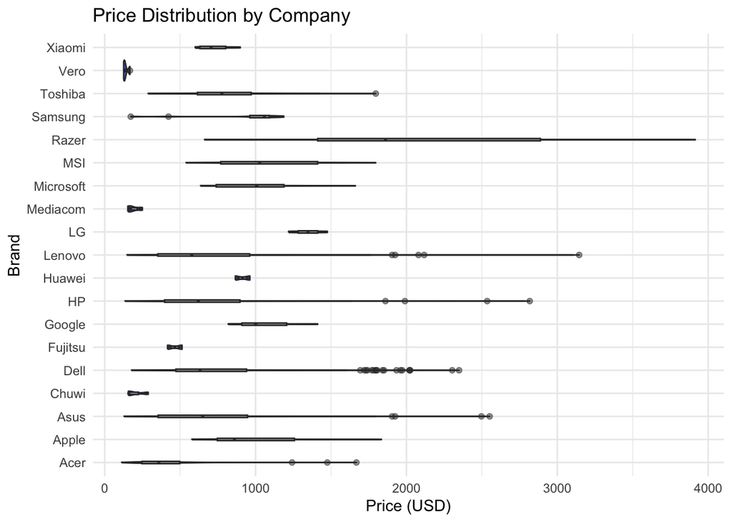

### By Laptop Type

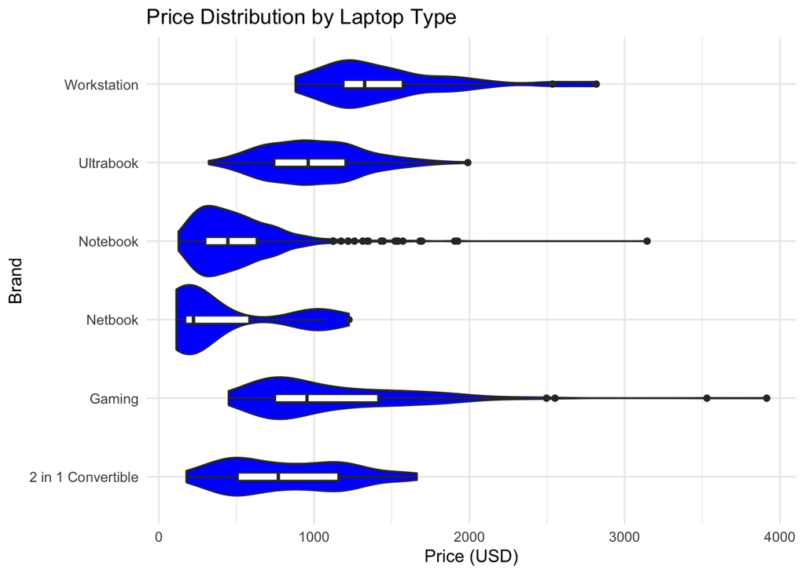

## Price Distribution Overlap

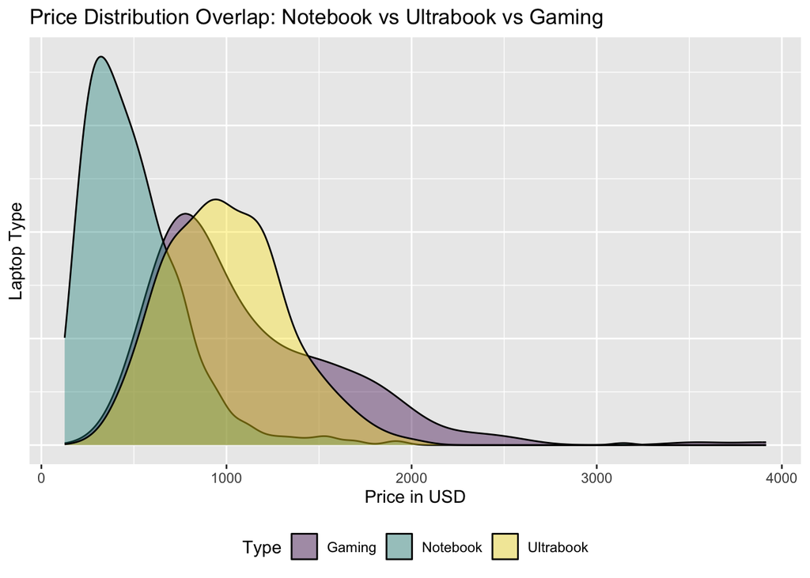